# Shootings in New York City - 2006 through 2020

# Report Introduction

Hello! Thank you for reading my report on shootings in New York City from 2006 through 2020. The analyses and visualizations contained herein are based on publicly available data provided by the New York Police Department, whose jurisdiction spans the five boroughs of New York City. You will find the packages that I’ve used, along with the code implemented to manipulate my data, throughout the rest of this section; subsequent sections will explore various relationships within this data set.

## Packages Implemented

```r
library(lubridate)
library(tidyverse)
library(dplyr)
library(RColorBrewer)
library(gbm)
library(caret)
```

## Data Source + Manipulation

```r
raw_data <- read.csv("https://data.cityofnewyork.us/api/views/833y-fsy8/rows.csv?accessType=DOWNLOAD")

clean_data <- raw_data %>%
                select(c(INCIDENT_KEY, OCCUR_DATE, OCCUR_TIME, PERP_SEX, VIC_SEX,
                        STATISTICAL_MURDER_FLAG, Latitude, Longitude, BORO)) %>%
                mutate(date = mdy(OCCUR_DATE)) %>%
                mutate(hour = as.integer(gsub(":","",substr(OCCUR_TIME, 1, 2)))) %>%
  mutate(month = month(date)) %>%
  mutate(day_of_week = ordered(weekdays(date), c("Sunday", "Monday", "Tuesday", "Wednesday", "Thursday", "Friday", "Saturday"))) %>%
  mutate(is_murder = as.logical(STATISTICAL_MURDER_FLAG)) %>%
  mutate(BORO = as.factor(BORO))

clean_data$PERP_SEX[clean_data$PERP_SEX == ""] <- "U"


summary(clean_data)
```

```
##   INCIDENT_KEY        OCCUR_DATE         OCCUR_TIME          PERP_SEX
##  Min.   :  9953245   Length:23568       Length:23568       Length:23568
##  1st Qu.: 55317014   Class :character   Class :character   Class :character
##  Median : 83365370   Mode  :character   Mode  :character   Mode  :character
##  Mean   :102218616
##  3rd Qu.:150772442
##  Max.   :222473262
##
##    VIC_SEX          STATISTICAL_MURDER_FLAG    Latitude       Longitude
##  Length:23568       Length:23568            Min.   :40.51   Min.   :-74.25
##  Class :character   Class :character        1st Qu.:40.67   1st Qu.:-73.94
##  Mode  :character   Mode  :character        Median :40.70   Median :-73.92
##                                             Mean   :40.74   Mean   :-73.91
##                                             3rd Qu.:40.82   3rd Qu.:-73.88
##                                             Max.   :40.91   Max.   :-73.70
##
##             BORO           date                 hour           month
##  BRONX        :6700   Min.   :2006-01-01   Min.   : 0.00   Min.   : 1.000
##  BROOKLYN     :9722   1st Qu.:2008-12-30   1st Qu.: 3.00   1st Qu.: 5.000
##  MANHATTAN    :2921   Median :2012-02-26   Median :15.00   Median : 7.000
##  QUEENS       :3527   Mean   :2012-10-03   Mean   :12.08   Mean   : 6.853
##  STATEN ISLAND: 698   3rd Qu.:2016-02-28   3rd Qu.:20.00   3rd Qu.: 9.000
##                       Max.   :2020-12-31   Max.   :23.00   Max.   :12.000
##
##     day_of_week   is_murder
##  Sunday   :4817   Mode :logical
##  Monday   :3309   FALSE:19080
##  Tuesday  :2694   TRUE :4488
##  Wednesday:2572
##  Thursday :2549
##  Friday   :3095
##  Saturday :4532
```

# Is There Gender Discrimination Amongst NYC Murderers?

## Intro

In a class that I took at Stony Brook University on the Sociology of Crime, we learned that approximately 8 in 10 murders are “intraracial” (i.e. white on white or black on black). A recent article from Reuters corroborates this notion: https://www.reuters.com/article/uk-factcheck-data-racial-murder-idUSKCN24I2A9

I thought it would be interesting to explore whether there is any bias in who murderers (and particularly, those who use guns) choose to kill on the basis of gender.

## Code/Analysis

### Data + Set-Up

```r
murder_data <- clean_data %>%
                  filter(is_murder == TRUE)
```

### Plots

#### Murders

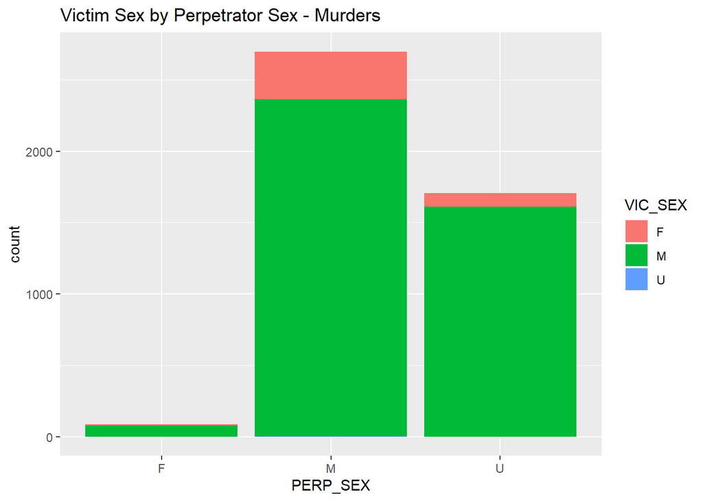

```r
perp_vs_vic_murder <- ggplot(murder_data, aes(PERP_SEX))
perp_vs_vic_murder + geom_bar(aes(fill = VIC_SEX)) +
  labs(title = "Victim Sex by Perpetrator Sex - Murders")
```

#### All Shootings

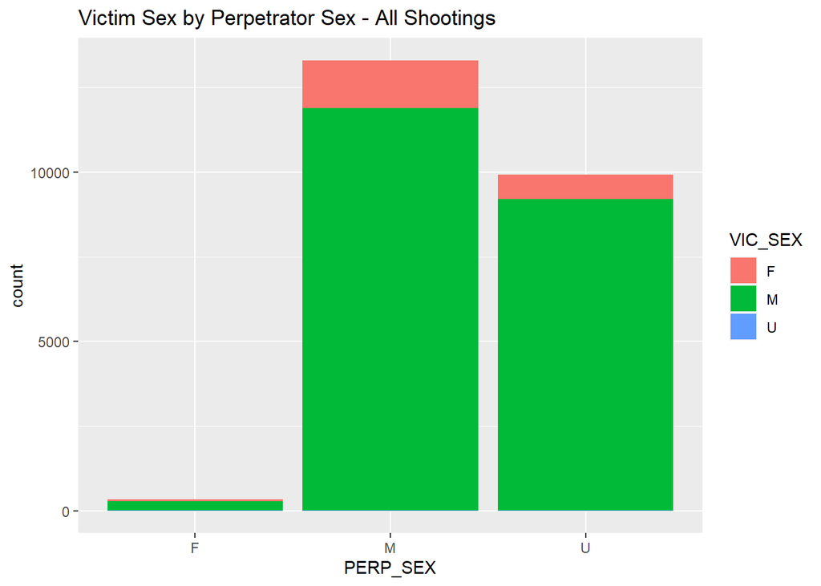

```r
perp_vs_vic_all <- ggplot(clean_data, aes(PERP_SEX))
perp_vs_vic_all + geom_bar(aes(fill = VIC_SEX)) +
  labs(title = "Victim Sex by Perpetrator Sex - All Shootings")
```

#### Perp by Victim

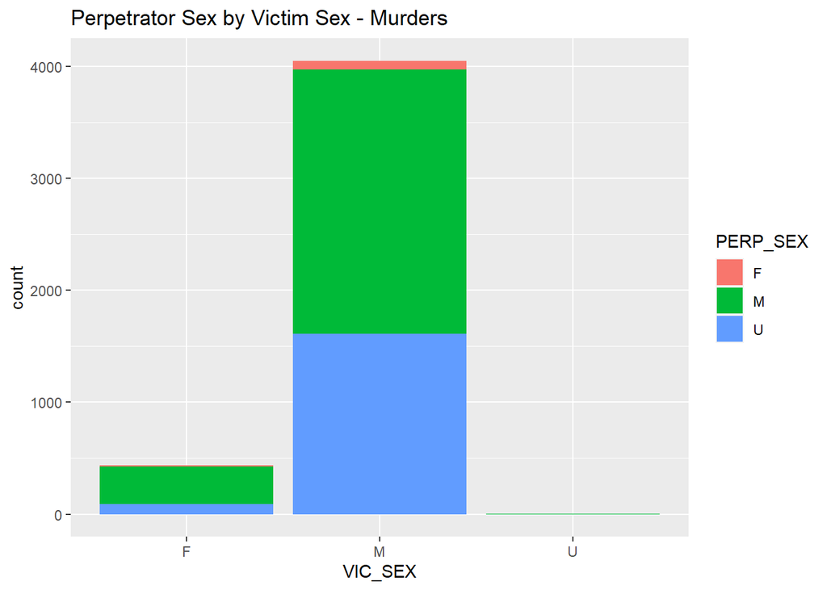

```r
vic_vs_perp <- ggplot(murder_data, aes(VIC_SEX))
vic_vs_perp + geom_bar(aes(fill = PERP_SEX)) +
  labs(title = "Perpetrator Sex by Victim Sex - Murders")
```

## Conclusions

Objectively, men commit more crimes (especially violent ones), so the distribution of murders by PERP_SEX is not too surprising; however, I did not expect the distribution by VIC_SEX to be so distorted. While there is possibly bias in the data to the extent that perpetrators who go unidentified may not be evenly distributed by gender, it is crystal clear that men comprise the vast majority of shooting victims (at least in New York City). In comparison with my original expectations:

- Murders committed by men are vastly “intragender,” which aligns with the general patterns observed by race.
- Murders committed by women swing the opposite direction; that is to say, the victims of shooting murders committed by women *also* show a strong bias towards male victims. Perhaps this is explainable, at least to some extent, by extenuating circumstances like domestic abuse or other forms of precedent victimization that these women are subject to.
- When we flip the axes and review the distribution of PERP_SEX by VIC_SEX, it is readily apparent that murderers of male victims (at least where firearms are involved) appear to go unidentified at a much higher rate than their counterparts who murder women.

# Do Different Boroughs See Different Frequency Distributions of Shootings?

## Intro

Having grown up in Queens, I’m tangentially familiar with the New York City commute. I’ve never had to make that trip for work myself, but millions of folks flock to NYC (and Manhattan in particular) from outlying boroughs, suburbs like Westchester and Long Island, and even other states like New Jersey and Connecticut. I would imagine that, given these dynamics, there will likely be an observable difference between the frequency of shootings by hour and day of week between boroughs.

## Code/Analysis

### Data + Set-Up

```r
# color code inspired by https://www.r-bloggers.com/2013/03/r-defining-your-own-color-schemes-for-heatmaps/
red=rgb(1,0,0); green=rgb(0,1,0); yellow=rgb(1,1,0)
GtoYrange<-colorRampPalette(c(green, yellow) )
YtoRrange<-colorRampPalette(c(yellow, red) )

shooting_time_data <- clean_data %>%
  group_by(BORO, day_of_week, hour) %>%
  count(hour)

boroughs <- c("QUEENS", "BROOKLYN", "BRONX", "MANHATTAN", "STATEN ISLAND")
queens_data <- shooting_time_data %>% filter(BORO == "QUEENS")
brooklyn_data <- shooting_time_data %>% filter(BORO == "BROOKLYN")
bronx_data <- shooting_time_data %>% filter(BORO == "BRONX")
manhattan_data <- shooting_time_data %>% filter(BORO == "MANHATTAN")
staten_data <- shooting_time_data %>% filter(BORO == "STATEN ISLAND")
```

### Plots

#### Queens

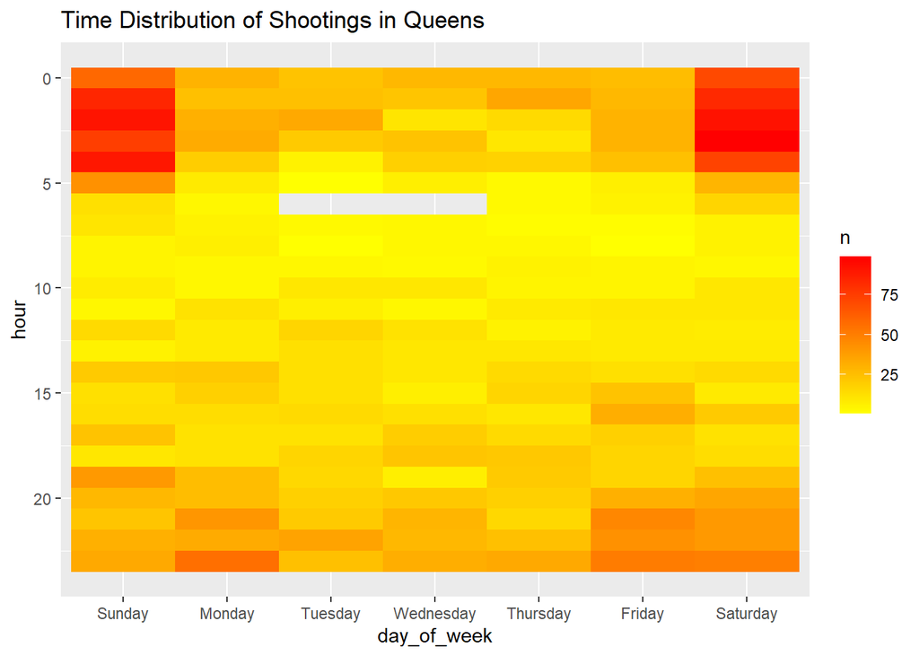

```r
ggplot(queens_data, aes(day_of_week, hour, fill= n)) +
    geom_tile() +
    ggtitle("Time Distribution of Shootings in Queens") +
    scale_y_reverse() +
    scale_fill_gradient2(low="gray", mid=GtoYrange(100), high=YtoRrange(100))
```

#### Brooklyn

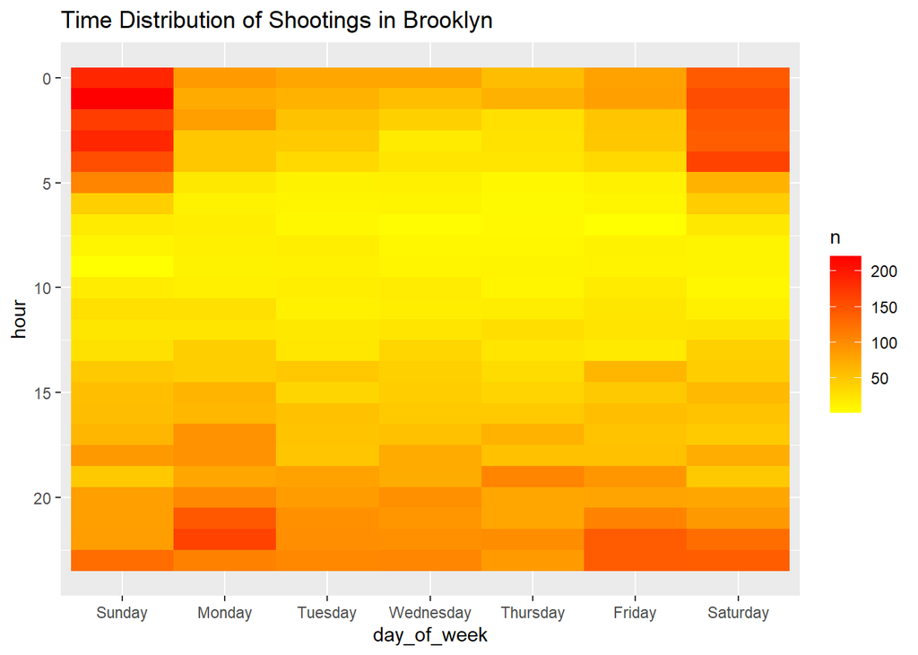

```r
ggplot(brooklyn_data, aes(day_of_week, hour, fill= n)) +
    geom_tile() +
    ggtitle("Time Distribution of Shootings in Brooklyn") +
    scale_y_reverse() +
    scale_fill_gradient2(low="gray", mid=GtoYrange(100), high=YtoRrange(100))
```

#### The Bronx

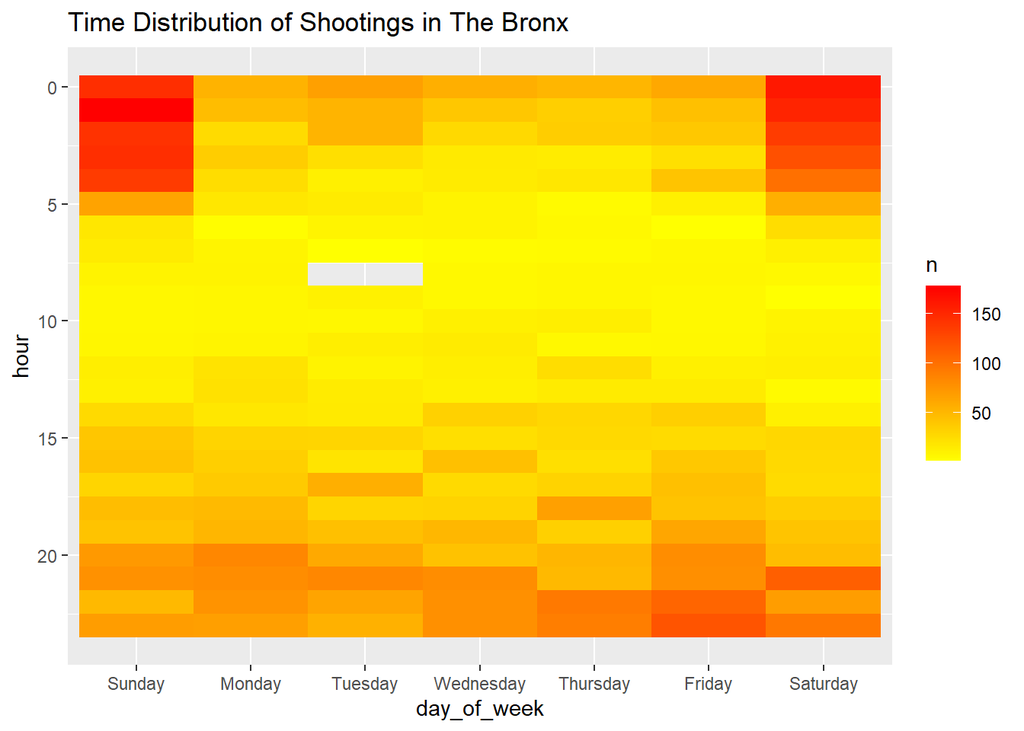

```r
ggplot(bronx_data, aes(day_of_week, hour, fill= n)) +
    geom_tile() +
    ggtitle("Time Distribution of Shootings in The Bronx") +
    scale_y_reverse() +
    scale_fill_gradient2(low="gray", mid=GtoYrange(100), high=YtoRrange(100))
```

#### Manhattan

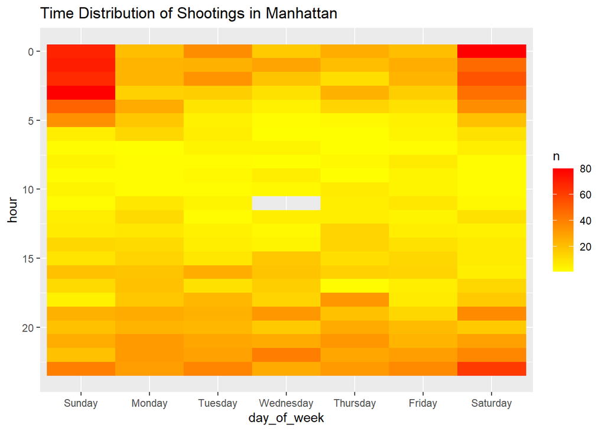

```r
ggplot(manhattan_data, aes(day_of_week, hour, fill= n)) +
    geom_tile() +
    ggtitle("Time Distribution of Shootings in Manhattan") +
    scale_y_reverse() +
    scale_fill_gradient2(low="gray", mid=GtoYrange(100), high=YtoRrange(100))
```

#### Staten Island

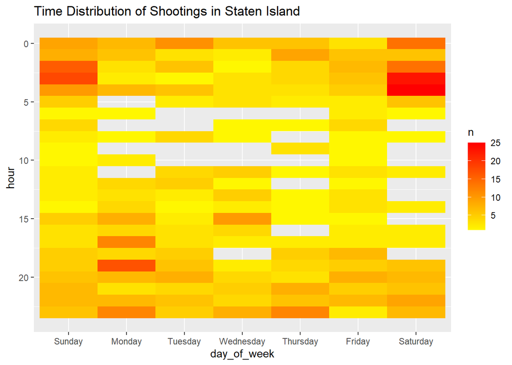

```r
ggplot(staten_data, aes(day_of_week, hour, fill= n)) +
    geom_tile() +
    ggtitle("Time Distribution of Shootings in Staten Island") +
    scale_y_reverse() +
    scale_fill_gradient2(low="gray", mid=GtoYrange(100), high=YtoRrange(100))
```

## Conclusions

# Time Series Modeling

## Intro

As we observed in the previous heatmap visualizations, there is a clear pattern of when shootings most typically occur that is observable across all five boroughs to some extent. This begs the question: can we predict how many shootings are expected to occur in each borough based on time alone? There are other factors at play; namely, population growth will likely cause an annual increase in the number of observed shootings, and weather-related patterns could induce more shootings in the summer when folks are outside/spend more time interacting. In a concerted effort to model these phenomena, I would likely pull in actual population data and weather data; however, in order to account for this simply with the data provided as part of this preliminary attempt, I will use year and month as proxies for population growth and climate (respectively). Ultimately, I hope to compare the predictions from this rudimentary model to the average rate of shootings per hour by borough in order to determine when specific boroughs are expected to disproportionately contribute to shootings.

## Code/Analysis

### Data + Set-Up

```r
all_times <- clean_data %>%
  mutate(year = year(date)) %>%
  expand(BORO, year, month, day_of_week, hour)

shooting_counts <- clean_data %>%
  mutate(year = year(date)) %>%
  group_by(BORO, year, month, day_of_week, hour) %>%
  count(hour)

nonzero_times <- subset(shooting_counts, select = -c(n))

zero_records <- anti_join(all_times, nonzero_times, by = c("BORO", "year", "month", "day_of_week", "hour")) %>%
  mutate(n = 0)

shooting_model_data <- rbind(shooting_counts, zero_records)
```

### Model Generation

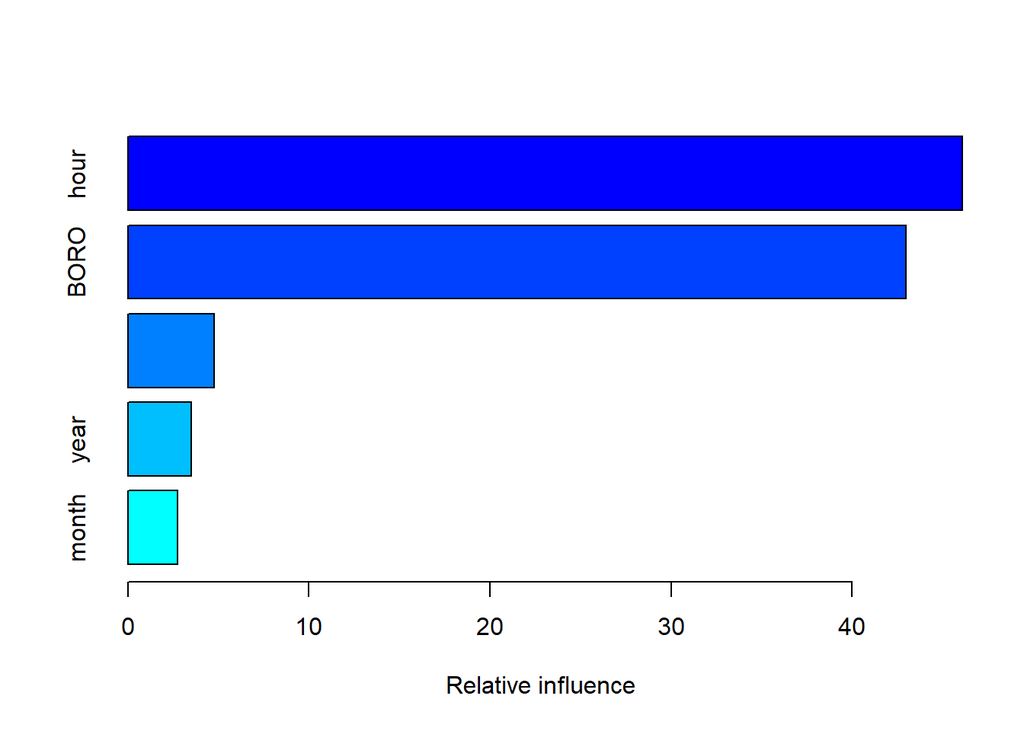

```
##                     var   rel.inf
## hour               hour 46.089625
## BORO               BORO 42.962148
## day_of_week day_of_week  4.744646
## year               year  3.481598
## month             month  2.721982
```

```r
# inspired by https://www.datatechnotes.com/2019/06/gradient-boosting-regression-example.html

indexes = createDataPartition(shooting_model_data$n, p = .90, list = F)
train = shooting_model_data[indexes, ]
test = shooting_model_data[-indexes, ]

model = gbm(train$n ~.,
                data = train,
                distribution = "poisson")

summary(model)
```

### Partial Dependency Plots

#### Year

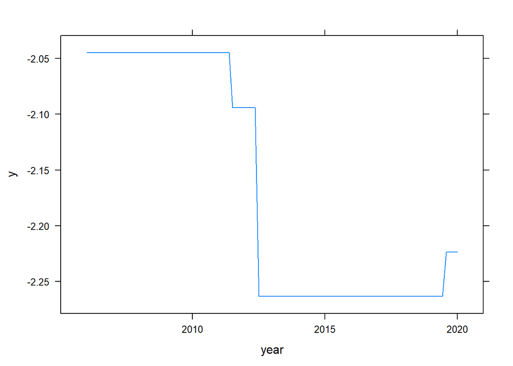

```r
plot(model, "year")
```

#### Month

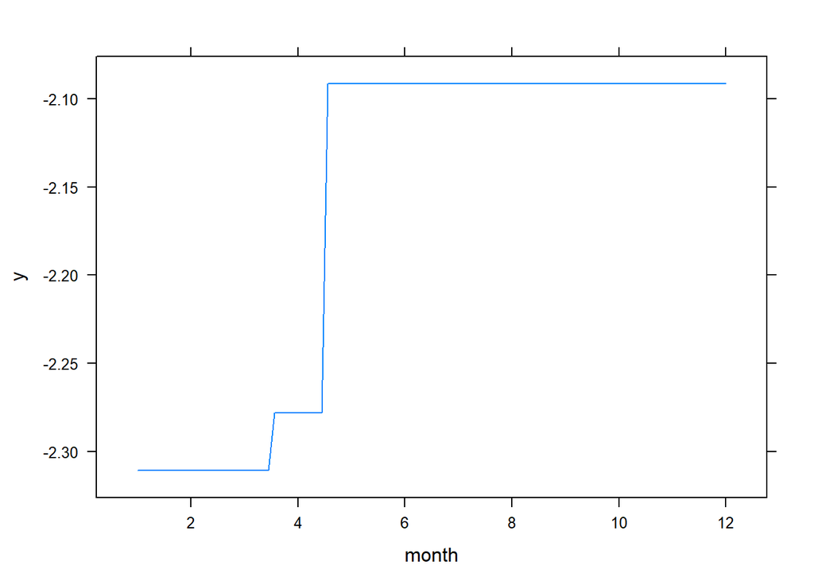

```r
plot(model, "month")
```

#### Hour

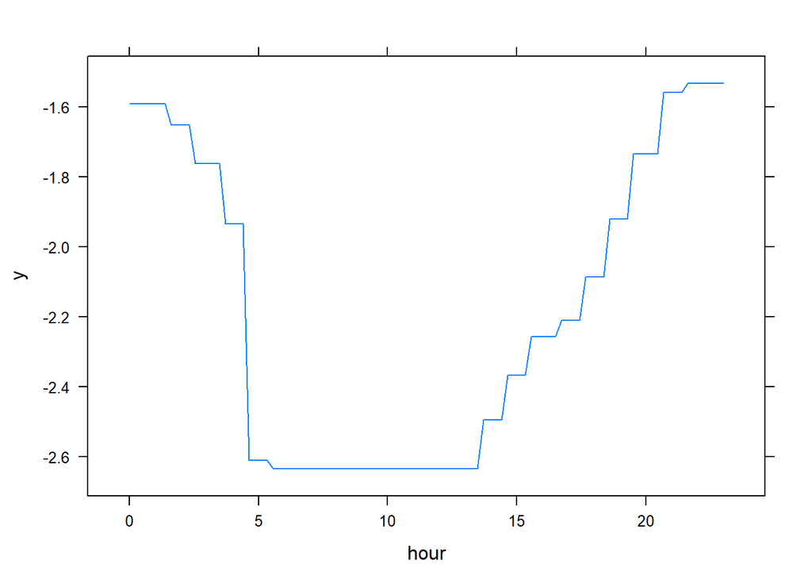

```r
plot(model, "hour")
```

#### Weekday

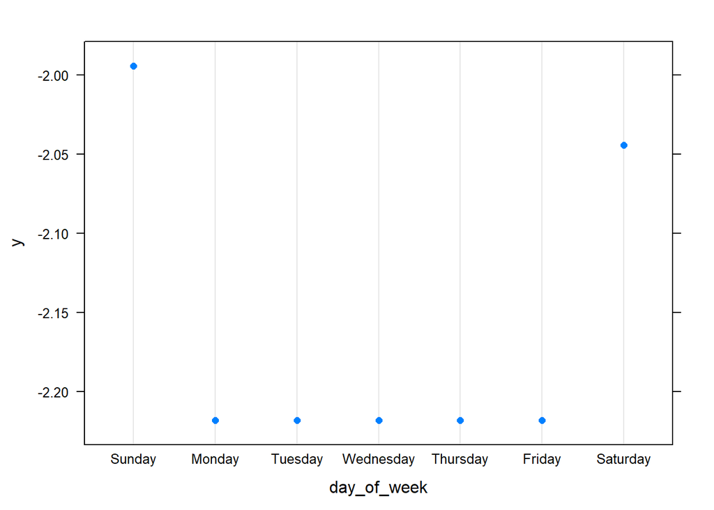

```r
plot(model, "day_of_week")
```

#### Borough

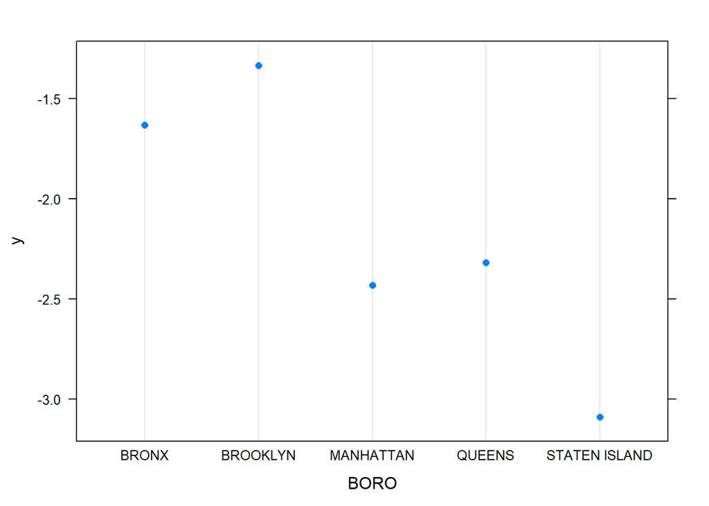

```r
plot(model, "BORO")
```

### Validation on Test Data

```r
train$preds <- predict.gbm(model, train)
```

```
## Using 100 trees...
```

```r
test$preds <- predict.gbm(model, test)
```

```
## Using 100 trees...
```

```r
RMSE(train$preds, train$n)
```

```
## [1] 2.465922
```

```r
RMSE(test$preds, test$n)
```

```
## [1] 2.473003
```

## Conclusions

A gradient boosted decision tree is not particularly useful for generating meaningful predictions from the data, as this specific type of model can generate negative values (which would be impossible to observe in reality). I plan to explore different model types/options in a future iteration of this report. That said, the conclusions that we can draw from the partial dependency plots are both useful and reasonable in most cases:

```r
shootings_dow <- clean_data %>%
  count(day_of_week)
shootings_dow
```

```
##   day_of_week    n
## 1      Sunday 4817
## 2      Monday 3309
## 3     Tuesday 2694
## 4   Wednesday 2572
## 5    Thursday 2549
## 6      Friday 3095
## 7    Saturday 4532
```

- Partial predictions of shooting frequency by borough indicate that Brooklyn and The Bronx are expected to observe markedly more frequent shootings than their counterparts. While Brooklyn’s position atop the “leaderboard” is to be expected considering it is New York City’s most populous borough, the fact that shootings in The Bronx (4th most populous) are expected to outpace both Queens and Manhattan (2nd and 3rd, respectively) is alarming to say the least. NYPD should consider devoting considerably more resources to policing The Bronx, specifically with an eye towards reducing gun violence there.